# Risk Factor Analysis

## Outcome Variable

**Outcome Variable:** y_rate_lencm

## Predictor Variables

**Intervention Variable:** hfoodsec

**Adjustment Set:**

unadjusted

## Stratifying Variables

The analysis was stratified on these variable(s):

- diffcat
- studyid
- country

## Data Summary

| diffcat | studyid | country | hfoodsec | n_cell | n |
| --- | --- | --- | --- | --- | --- |
| 0-3 months | ki0047075b-MAL-ED | BANGLADESH | Food Secure | 160 | 192 |
| 0-3 months | ki0047075b-MAL-ED | BANGLADESH | Mildly Food Insecure | 4 | 192 |
| 0-3 months | ki0047075b-MAL-ED | BANGLADESH | Moderately Food Insecure | 22 | 192 |
| 0-3 months | ki0047075b-MAL-ED | BANGLADESH | Severely Food Insecure | 6 | 192 |
| 3-6 months | ki0047075b-MAL-ED | BANGLADESH | Food Secure | 156 | 189 |
| 3-6 months | ki0047075b-MAL-ED | BANGLADESH | Mildly Food Insecure | 4 | 189 |
| 3-6 months | ki0047075b-MAL-ED | BANGLADESH | Moderately Food Insecure | 23 | 189 |
| 3-6 months | ki0047075b-MAL-ED | BANGLADESH | Severely Food Insecure | 6 | 189 |
| 6-12 months | ki0047075b-MAL-ED | BANGLADESH | Food Secure | 154 | 186 |
| 6-12 months | ki0047075b-MAL-ED | BANGLADESH | Mildly Food Insecure | 4 | 186 |
| 6-12 months | ki0047075b-MAL-ED | BANGLADESH | Moderately Food Insecure | 22 | 186 |
| 6-12 months | ki0047075b-MAL-ED | BANGLADESH | Severely Food Insecure | 6 | 186 |
| 12-24 months | ki0047075b-MAL-ED | BANGLADESH | Food Secure | 156 | 188 |
| 12-24 months | ki0047075b-MAL-ED | BANGLADESH | Mildly Food Insecure | 4 | 188 |
| 12-24 months | ki0047075b-MAL-ED | BANGLADESH | Moderately Food Insecure | 22 | 188 |
| 12-24 months | ki0047075b-MAL-ED | BANGLADESH | Severely Food Insecure | 6 | 188 |
| 12-24 months | ki1000110-WASH-Bangladesh | BANGLADESH | Food Secure | 24 | 38 |
| 12-24 months | ki1000110-WASH-Bangladesh | BANGLADESH | Mildly Food Insecure | 4 | 38 |
| 12-24 months | ki1000110-WASH-Bangladesh | BANGLADESH | Moderately Food Insecure | 6 | 38 |
| 12-24 months | ki1000110-WASH-Bangladesh | BANGLADESH | Severely Food Insecure | 4 | 38 |
| 0-3 months | ki1017093-NIH-Birth | BANGLADESH | Food Secure | 83 | 566 |
| 0-3 months | ki1017093-NIH-Birth | BANGLADESH | Mildly Food Insecure | 444 | 566 |
| 0-3 months | ki1017093-NIH-Birth | BANGLADESH | Moderately Food Insecure | 34 | 566 |
| 0-3 months | ki1017093-NIH-Birth | BANGLADESH | Severely Food Insecure | 5 | 566 |
| 3-6 months | ki1017093-NIH-Birth | BANGLADESH | Food Secure | 77 | 523 |
| 3-6 months | ki1017093-NIH-Birth | BANGLADESH | Mildly Food Insecure | 407 | 523 |
| 3-6 months | ki1017093-NIH-Birth | BANGLADESH | Moderately Food Insecure | 35 | 523 |
| 3-6 months | ki1017093-NIH-Birth | BANGLADESH | Severely Food Insecure | 4 | 523 |
| 6-12 months | ki1017093-NIH-Birth | BANGLADESH | Food Secure | 74 | 482 |
| 6-12 months | ki1017093-NIH-Birth | BANGLADESH | Mildly Food Insecure | 370 | 482 |

[output cut: 156 more lines]

The following strata were considered:

- diffcat: 0-3 months, studyid: ki0047075b-MAL-ED, country: BANGLADESH
- diffcat: 0-3 months, studyid: ki0047075b-MAL-ED, country: BRAZIL
- diffcat: 0-3 months, studyid: ki0047075b-MAL-ED, country: INDIA
- diffcat: 0-3 months, studyid: ki0047075b-MAL-ED, country: NEPAL
- diffcat: 0-3 months, studyid: ki0047075b-MAL-ED, country: PERU
- diffcat: 0-3 months, studyid: ki0047075b-MAL-ED, country: SOUTH AFRICA
- diffcat: 0-3 months, studyid: ki1017093-NIH-Birth, country: BANGLADESH
- diffcat: 0-3 months, studyid: ki1017093c-NIH-Crypto, country: BANGLADESH
- diffcat: 0-3 months, studyid: kiGH5241-JiVitA-3, country: BANGLADESH
- diffcat: 0-3 months, studyid: kiGH5241-JiVitA-4, country: BANGLADESH
- diffcat: 12-24 months, studyid: ki0047075b-MAL-ED, country: BANGLADESH
- diffcat: 12-24 months, studyid: ki0047075b-MAL-ED, country: BRAZIL
- diffcat: 12-24 months, studyid: ki0047075b-MAL-ED, country: INDIA
- diffcat: 12-24 months, studyid: ki0047075b-MAL-ED, country: NEPAL
- diffcat: 12-24 months, studyid: ki0047075b-MAL-ED, country: PERU
- diffcat: 12-24 months, studyid: ki0047075b-MAL-ED, country: SOUTH AFRICA
- diffcat: 12-24 months, studyid: ki1000110-WASH-Bangladesh, country: BANGLADESH
- diffcat: 12-24 months, studyid: ki1017093-NIH-Birth, country: BANGLADESH
- diffcat: 12-24 months, studyid: ki1017093c-NIH-Crypto, country: BANGLADESH
- diffcat: 12-24 months, studyid: ki1113344-GMS-Nepal, country: NEPAL
- diffcat: 12-24 months, studyid: ki1148112-iLiNS-DOSE, country: MALAWI
- diffcat: 12-24 months, studyid: ki1148112-iLiNS-DYAD-M, country: MALAWI
- diffcat: 12-24 months, studyid: kiGH5241-JiVitA-3, country: BANGLADESH
- diffcat: 12-24 months, studyid: kiGH5241-JiVitA-4, country: BANGLADESH
- diffcat: 3-6 months, studyid: ki0047075b-MAL-ED, country: BANGLADESH
- diffcat: 3-6 months, studyid: ki0047075b-MAL-ED, country: BRAZIL
- diffcat: 3-6 months, studyid: ki0047075b-MAL-ED, country: INDIA
- diffcat: 3-6 months, studyid: ki0047075b-MAL-ED, country: NEPAL
- diffcat: 3-6 months, studyid: ki0047075b-MAL-ED, country: PERU
- diffcat: 3-6 months, studyid: ki0047075b-MAL-ED, country: SOUTH AFRICA
- diffcat: 3-6 months, studyid: ki1017093-NIH-Birth, country: BANGLADESH
- diffcat: 3-6 months, studyid: ki1017093c-NIH-Crypto, country: BANGLADESH
- diffcat: 3-6 months, studyid: ki1113344-GMS-Nepal, country: NEPAL
- diffcat: 3-6 months, studyid: ki1148112-iLiNS-DYAD-M, country: MALAWI
- diffcat: 3-6 months, studyid: kiGH5241-JiVitA-3, country: BANGLADESH
- diffcat: 3-6 months, studyid: kiGH5241-JiVitA-4, country: BANGLADESH
- diffcat: 6-12 months, studyid: ki0047075b-MAL-ED, country: BANGLADESH
- diffcat: 6-12 months, studyid: ki0047075b-MAL-ED, country: BRAZIL
- diffcat: 6-12 months, studyid: ki0047075b-MAL-ED, country: INDIA
- diffcat: 6-12 months, studyid: ki0047075b-MAL-ED, country: NEPAL
- diffcat: 6-12 months, studyid: ki0047075b-MAL-ED, country: PERU
- diffcat: 6-12 months, studyid: ki0047075b-MAL-ED, country: SOUTH AFRICA
- diffcat: 6-12 months, studyid: ki1017093-NIH-Birth, country: BANGLADESH
- diffcat: 6-12 months, studyid: ki1017093c-NIH-Crypto, country: BANGLADESH
- diffcat: 6-12 months, studyid: ki1113344-GMS-Nepal, country: NEPAL
- diffcat: 6-12 months, studyid: ki1148112-iLiNS-DOSE, country: MALAWI
- diffcat: 6-12 months, studyid: ki1148112-iLiNS-DYAD-M, country: MALAWI
- diffcat: 6-12 months, studyid: kiGH5241-JiVitA-3, country: BANGLADESH
- diffcat: 6-12 months, studyid: kiGH5241-JiVitA-4, country: BANGLADESH

### Dropped Strata

Some strata were dropped due to rare outcomes:

- diffcat: 0-3 months, studyid: ki0047075b-MAL-ED, country: BANGLADESH
- diffcat: 3-6 months, studyid: ki0047075b-MAL-ED, country: BANGLADESH
- diffcat: 6-12 months, studyid: ki0047075b-MAL-ED, country: BANGLADESH
- diffcat: 12-24 months, studyid: ki0047075b-MAL-ED, country: BANGLADESH
- diffcat: 12-24 months, studyid: ki1000110-WASH-Bangladesh, country: BANGLADESH
- diffcat: 3-6 months, studyid: ki1017093-NIH-Birth, country: BANGLADESH
- diffcat: 6-12 months, studyid: ki1017093-NIH-Birth, country: BANGLADESH
- diffcat: 12-24 months, studyid: ki1017093-NIH-Birth, country: BANGLADESH
- diffcat: 3-6 months, studyid: ki0047075b-MAL-ED, country: BRAZIL
- diffcat: 6-12 months, studyid: ki0047075b-MAL-ED, country: BRAZIL
- diffcat: 12-24 months, studyid: ki0047075b-MAL-ED, country: BRAZIL
- diffcat: 0-3 months, studyid: ki0047075b-MAL-ED, country: INDIA
- diffcat: 3-6 months, studyid: ki0047075b-MAL-ED, country: INDIA
- diffcat: 6-12 months, studyid: ki0047075b-MAL-ED, country: INDIA
- diffcat: 12-24 months, studyid: ki0047075b-MAL-ED, country: INDIA
- diffcat: 3-6 months, studyid: ki1148112-iLiNS-DYAD-M, country: MALAWI
- diffcat: 0-3 months, studyid: ki0047075b-MAL-ED, country: NEPAL
- diffcat: 3-6 months, studyid: ki0047075b-MAL-ED, country: NEPAL
- diffcat: 6-12 months, studyid: ki0047075b-MAL-ED, country: NEPAL
- diffcat: 12-24 months, studyid: ki0047075b-MAL-ED, country: NEPAL

## Methods Detail

We’re interested in the causal parameters $E[Y_a]$ for all values of $a \in \mathcal{A}$. These parameters represent the mean outcome if, possibly contrary to fact, we intervened to set all units to have $A=a$. Under the randomization and positivity assumptions, these are identified by the statistical parameters $\psi_a=E_W[E_{Y|A,W}(Y|A=a,W)]$. In addition, we’re interested in the mean of $Y$, $E[Y]$ under no intervention (the observed mean). We will estimate these parameters by using SuperLearner to fit the relevant likelihood factors – $E_{Y|A,W}(Y|A=a,W)$ and $p(A=a|W)$, and then updating our likelihood fit using a joint TMLE.

For unadjusted analyses ($W=\{\}$), initial likelihoods were estimated using Lrnr_glm to estimate the simple $E(Y|A)$ and Lrnr_mean to estimate $p(A)$. For adjusted analyses, a small library containing Lrnr_glmnet, Lrnr_xgboost, and Lrnr_mean was used.

Having estimated these parameters, we will then use the delta method to estimate relative risks and attributable risks relative to a prespecified baseline level of $A$.

# Results Detail

## Results Plots

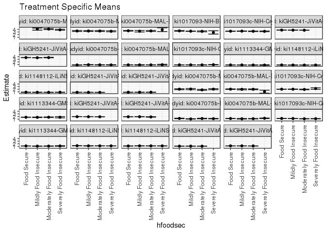

[figure not shown]

## Results Table

### Parameter: TSM

| diffcat | studyid | country | intervention_level | baseline_level | estimate | ci_lower | ci_upper |
| --- | --- | --- | --- | --- | --- | --- | --- |
| 0-3 months | ki0047075b-MAL-ED | BRAZIL | Mildly Food Insecure | NA | 4.1043537 | 3.7006279 | 4.5080795 |
| 0-3 months | ki0047075b-MAL-ED | BRAZIL | Moderately Food Insecure | NA | 4.1257115 | 3.9365670 | 4.3148560 |
| 0-3 months | ki0047075b-MAL-ED | BRAZIL | Severely Food Insecure | NA | 3.8476331 | 3.6595318 | 4.0357344 |
| 0-3 months | ki0047075b-MAL-ED | PERU | Food Secure | NA | 3.3863896 | 3.1984358 | 3.5743435 |
| 0-3 months | ki0047075b-MAL-ED | PERU | Mildly Food Insecure | NA | 3.3789941 | 3.2244810 | 3.5335072 |
| 0-3 months | ki0047075b-MAL-ED | PERU | Moderately Food Insecure | NA | 3.3764463 | 3.1940940 | 3.5587985 |
| 0-3 months | ki0047075b-MAL-ED | PERU | Severely Food Insecure | NA | 3.2741826 | 3.0760816 | 3.4722836 |
| 0-3 months | ki0047075b-MAL-ED | SOUTH AFRICA | Food Secure | NA | 3.4630577 | 3.3436425 | 3.5824729 |
| 0-3 months | ki0047075b-MAL-ED | SOUTH AFRICA | Mildly Food Insecure | NA | 3.3022696 | 3.0038121 | 3.6007270 |
| 0-3 months | ki0047075b-MAL-ED | SOUTH AFRICA | Moderately Food Insecure | NA | 3.4092730 | 3.2239890 | 3.5945570 |
| 0-3 months | ki0047075b-MAL-ED | SOUTH AFRICA | Severely Food Insecure | NA | 3.8629673 | 3.1460696 | 4.5798650 |
| 0-3 months | ki1017093-NIH-Birth | BANGLADESH | Food Secure | NA | 3.4288648 | 3.2820555 | 3.5756741 |
| 0-3 months | ki1017093-NIH-Birth | BANGLADESH | Mildly Food Insecure | NA | 3.3014725 | 3.2395868 | 3.3633582 |
| 0-3 months | ki1017093-NIH-Birth | BANGLADESH | Moderately Food Insecure | NA | 3.2499102 | 3.0665458 | 3.4332746 |
| 0-3 months | ki1017093-NIH-Birth | BANGLADESH | Severely Food Insecure | NA | 2.8338589 | 2.1993439 | 3.4683738 |
| 0-3 months | ki1017093c-NIH-Crypto | BANGLADESH | Food Secure | NA | 3.2950371 | 3.2443838 | 3.3456904 |
| 0-3 months | ki1017093c-NIH-Crypto | BANGLADESH | Mildly Food Insecure | NA | 3.3343952 | 3.2624283 | 3.4063622 |
| 0-3 months | ki1017093c-NIH-Crypto | BANGLADESH | Moderately Food Insecure | NA | 3.2732579 | 3.1560119 | 3.3905039 |
| 0-3 months | ki1017093c-NIH-Crypto | BANGLADESH | Severely Food Insecure | NA | 3.2466911 | 3.1007429 | 3.3926394 |
| 0-3 months | kiGH5241-JiVitA-3 | BANGLADESH | Food Secure | NA | 3.7410012 | 3.7259325 | 3.7560699 |
| 0-3 months | kiGH5241-JiVitA-3 | BANGLADESH | Mildly Food Insecure | NA | 3.7082767 | 3.6895157 | 3.7270376 |
| 0-3 months | kiGH5241-JiVitA-3 | BANGLADESH | Moderately Food Insecure | NA | 3.6723346 | 3.6439165 | 3.7007528 |
| 0-3 months | kiGH5241-JiVitA-4 | BANGLADESH | Food Secure | NA | 3.6600913 | 3.6158179 | 3.7043646 |
| 0-3 months | kiGH5241-JiVitA-4 | BANGLADESH | Mildly Food Insecure | NA | 3.6019640 | 3.5519398 | 3.6519882 |
| 0-3 months | kiGH5241-JiVitA-4 | BANGLADESH | Moderately Food Insecure | NA | 3.6568637 | 3.5566386 | 3.7570887 |
| 3-6 months | ki0047075b-MAL-ED | PERU | Food Secure | NA | 2.0055653 | 1.8227743 | 2.1883563 |
| 3-6 months | ki0047075b-MAL-ED | PERU | Mildly Food Insecure | NA | 2.0435365 | 1.8294004 | 2.2576725 |
| 3-6 months | ki0047075b-MAL-ED | PERU | Moderately Food Insecure | NA | 1.7424879 | 1.5592672 | 1.9257086 |
| 3-6 months | ki0047075b-MAL-ED | PERU | Severely Food Insecure | NA | 2.0223862 | 1.8200114 | 2.2247610 |
| 3-6 months | ki0047075b-MAL-ED | SOUTH AFRICA | Food Secure | NA | 2.0181595 | 1.9079634 | 2.1283556 |

[output cut: 77 more lines]

### Parameter: E(Y)

| diffcat | studyid | country | intervention_level | baseline_level | estimate | ci_lower | ci_upper |
| --- | --- | --- | --- | --- | --- | --- | --- |
| 0-3 months | ki0047075b-MAL-ED | BRAZIL | NA | NA | 4.0175394 | 3.8869881 | 4.1480907 |
| 0-3 months | ki0047075b-MAL-ED | PERU | NA | NA | 3.3547253 | 3.2634611 | 3.4459896 |
| 0-3 months | ki0047075b-MAL-ED | SOUTH AFRICA | NA | NA | 3.4411414 | 3.3443437 | 3.5379390 |
| 0-3 months | ki1017093-NIH-Birth | BANGLADESH | NA | NA | 3.3129255 | 3.2581305 | 3.3677204 |
| 0-3 months | ki1017093c-NIH-Crypto | BANGLADESH | NA | NA | 3.3028656 | 3.2646714 | 3.3410598 |
| 0-3 months | kiGH5241-JiVitA-3 | BANGLADESH | NA | NA | 3.7183193 | 3.7063844 | 3.7302541 |
| 0-3 months | kiGH5241-JiVitA-4 | BANGLADESH | NA | NA | 3.6391263 | 3.6075490 | 3.6707036 |
| 3-6 months | ki0047075b-MAL-ED | PERU | NA | NA | 1.9530249 | 1.8522017 | 2.0538480 |
| 3-6 months | ki0047075b-MAL-ED | SOUTH AFRICA | NA | NA | 1.9716570 | 1.8866692 | 2.0566449 |
| 3-6 months | ki1017093c-NIH-Crypto | BANGLADESH | NA | NA | 2.0057973 | 1.9693775 | 2.0422170 |
| 3-6 months | ki1113344-GMS-Nepal | NEPAL | NA | NA | 1.7061500 | 1.6667551 | 1.7455449 |
| 3-6 months | kiGH5241-JiVitA-3 | BANGLADESH | NA | NA | 1.9201098 | 1.9096479 | 1.9305717 |
| 3-6 months | kiGH5241-JiVitA-4 | BANGLADESH | NA | NA | 1.8993572 | 1.8693950 | 1.9293194 |
| 6-12 months | ki0047075b-MAL-ED | PERU | NA | NA | 1.1824866 | 1.1320801 | 1.2328932 |
| 6-12 months | ki0047075b-MAL-ED | SOUTH AFRICA | NA | NA | 1.1940035 | 1.1512681 | 1.2367388 |
| 6-12 months | ki1017093c-NIH-Crypto | BANGLADESH | NA | NA | 1.2281313 | 1.2106849 | 1.2455776 |
| 6-12 months | ki1113344-GMS-Nepal | NEPAL | NA | NA | 1.1725665 | 1.1528638 | 1.1922692 |
| 6-12 months | ki1148112-iLiNS-DOSE | MALAWI | NA | NA | 1.2223766 | 1.2053824 | 1.2393708 |
| 6-12 months | ki1148112-iLiNS-DYAD-M | MALAWI | NA | NA | 1.1972845 | 1.1736230 | 1.2209460 |
| 6-12 months | kiGH5241-JiVitA-3 | BANGLADESH | NA | NA | 1.1069878 | 1.1002423 | 1.1137334 |
| 6-12 months | kiGH5241-JiVitA-4 | BANGLADESH | NA | NA | 1.2029754 | 1.1926285 | 1.2133223 |
| 12-24 months | ki0047075b-MAL-ED | PERU | NA | NA | 0.8709334 | 0.8403674 | 0.9014995 |
| 12-24 months | ki0047075b-MAL-ED | SOUTH AFRICA | NA | NA | 0.8714362 | 0.8487736 | 0.8940987 |
| 12-24 months | ki1017093c-NIH-Crypto | BANGLADESH | NA | NA | 0.8755729 | 0.8637860 | 0.8873598 |
| 12-24 months | ki1113344-GMS-Nepal | NEPAL | NA | NA | 0.8385573 | 0.8230446 | 0.8540700 |
| 12-24 months | ki1148112-iLiNS-DOSE | MALAWI | NA | NA | 0.8062704 | 0.7923680 | 0.8201728 |
| 12-24 months | ki1148112-iLiNS-DYAD-M | MALAWI | NA | NA | 0.8311052 | 0.8161568 | 0.8460535 |
| 12-24 months | kiGH5241-JiVitA-3 | BANGLADESH | NA | NA | 0.7968476 | 0.7915393 | 0.8021560 |
| 12-24 months | kiGH5241-JiVitA-4 | BANGLADESH | NA | NA | 0.8495388 | 0.8441127 | 0.8549650 |

### Parameter: ATE

| diffcat | studyid | country | intervention_level | baseline_level | estimate | ci_lower | ci_upper |
| --- | --- | --- | --- | --- | --- | --- | --- |
| 0-3 months | ki0047075b-MAL-ED | BRAZIL | Mildly Food Insecure | Mildly Food Insecure | 0.0000000 | 0.0000000 | 0.0000000 |
| 0-3 months | ki0047075b-MAL-ED | BRAZIL | Moderately Food Insecure | Mildly Food Insecure | 0.0213578 | -0.4244786 | 0.4671943 |
| 0-3 months | ki0047075b-MAL-ED | BRAZIL | Severely Food Insecure | Mildly Food Insecure | -0.2567206 | -0.7021155 | 0.1886743 |
| 0-3 months | ki0047075b-MAL-ED | PERU | Food Secure | Food Secure | 0.0000000 | 0.0000000 | 0.0000000 |
| 0-3 months | ki0047075b-MAL-ED | PERU | Mildly Food Insecure | Food Secure | -0.0073955 | -0.2507080 | 0.2359169 |
| 0-3 months | ki0047075b-MAL-ED | PERU | Moderately Food Insecure | Food Secure | -0.0099434 | -0.2718193 | 0.2519325 |
| 0-3 months | ki0047075b-MAL-ED | PERU | Severely Food Insecure | Food Secure | -0.1122070 | -0.3852833 | 0.1608693 |
| 0-3 months | ki0047075b-MAL-ED | SOUTH AFRICA | Food Secure | Food Secure | 0.0000000 | 0.0000000 | 0.0000000 |
| 0-3 months | ki0047075b-MAL-ED | SOUTH AFRICA | Mildly Food Insecure | Food Secure | -0.1607882 | -0.4822486 | 0.1606723 |
| 0-3 months | ki0047075b-MAL-ED | SOUTH AFRICA | Moderately Food Insecure | Food Secure | -0.0537847 | -0.2742165 | 0.1666470 |
| 0-3 months | ki0047075b-MAL-ED | SOUTH AFRICA | Severely Food Insecure | Food Secure | 0.3999096 | -0.3268657 | 1.1266849 |
| 0-3 months | ki1017093-NIH-Birth | BANGLADESH | Food Secure | Food Secure | 0.0000000 | 0.0000000 | 0.0000000 |
| 0-3 months | ki1017093-NIH-Birth | BANGLADESH | Mildly Food Insecure | Food Secure | -0.1273923 | -0.2867122 | 0.0319276 |
| 0-3 months | ki1017093-NIH-Birth | BANGLADESH | Moderately Food Insecure | Food Secure | -0.1789546 | -0.4138492 | 0.0559400 |
| 0-3 months | ki1017093-NIH-Birth | BANGLADESH | Severely Food Insecure | Food Secure | -0.5950059 | -1.2462833 | 0.0562714 |
| 0-3 months | ki1017093c-NIH-Crypto | BANGLADESH | Food Secure | Food Secure | 0.0000000 | 0.0000000 | 0.0000000 |
| 0-3 months | ki1017093c-NIH-Crypto | BANGLADESH | Mildly Food Insecure | Food Secure | 0.0393582 | -0.0486475 | 0.1273638 |
| 0-3 months | ki1017093c-NIH-Crypto | BANGLADESH | Moderately Food Insecure | Food Secure | -0.0217792 | -0.1494991 | 0.1059408 |
| 0-3 months | ki1017093c-NIH-Crypto | BANGLADESH | Severely Food Insecure | Food Secure | -0.0483459 | -0.2028343 | 0.1061424 |
| 0-3 months | kiGH5241-JiVitA-3 | BANGLADESH | Food Secure | Food Secure | 0.0000000 | 0.0000000 | 0.0000000 |
| 0-3 months | kiGH5241-JiVitA-3 | BANGLADESH | Mildly Food Insecure | Food Secure | -0.0327246 | -0.0559293 | -0.0095198 |
| 0-3 months | kiGH5241-JiVitA-3 | BANGLADESH | Moderately Food Insecure | Food Secure | -0.0686666 | -0.0988987 | -0.0384344 |
| 0-3 months | kiGH5241-JiVitA-4 | BANGLADESH | Food Secure | Food Secure | 0.0000000 | 0.0000000 | 0.0000000 |
| 0-3 months | kiGH5241-JiVitA-4 | BANGLADESH | Mildly Food Insecure | Food Secure | -0.0581273 | -0.1265327 | 0.0102780 |
| 0-3 months | kiGH5241-JiVitA-4 | BANGLADESH | Moderately Food Insecure | Food Secure | -0.0032276 | -0.1121533 | 0.1056981 |
| 3-6 months | ki0047075b-MAL-ED | PERU | Food Secure | Food Secure | 0.0000000 | 0.0000000 | 0.0000000 |
| 3-6 months | ki0047075b-MAL-ED | PERU | Mildly Food Insecure | Food Secure | 0.0379712 | -0.2435724 | 0.3195148 |
| 3-6 months | ki0047075b-MAL-ED | PERU | Moderately Food Insecure | Food Secure | -0.2630773 | -0.5218869 | -0.0042678 |
| 3-6 months | ki0047075b-MAL-ED | PERU | Severely Food Insecure | Food Secure | 0.0168209 | -0.2558842 | 0.2895261 |
| 3-6 months | ki0047075b-MAL-ED | SOUTH AFRICA | Food Secure | Food Secure | 0.0000000 | 0.0000000 | 0.0000000 |

[output cut: 77 more lines]